# SimCOVID-19

Simulation of the SARS-CoV-2 pandemic virus outbreak which cause the corona virus disease 2019 (COVID-19) by using a modified S. E. I. R. D. model. **This repository is currently in a preview state! It should be used with caution!** Currently only German data has been processed, other countries will follow. Further questions can answered by soeren.thiering@hs-anhalt.de

## Data

Thanks for sharing the data by Johns Hopkins CSSE (https://systems.jhu.edu/research/public-health/ncov/).

## Model

[figure not shown]

Model

**Parameter:**

| Name | Value | Description | Source |
| --- | --- | --- | --- |
|  | ~ 0.15 to 0.4 | growth rate |  |
|  | 83019213 | max inahbitants |  |
|  | 5.1 | exposed / incubation time |  |
|  | 13 | time of a moderate infection |  |
|  | 8 | time until hostspitalisation |  |
|  | 10 | time for hostspitalisation with ARDS |  |
|  | 10 | time after ARDS |  |
|  | 2.5 | time until death while ARDS |  |
|  | 28031 | max intensive beds for treating ARDS |  |
|  | 0.14 | propotion hostspitalisation with ARDS |  |
|  | ~ 0.05 | propotion deaths |  |
|  | 0.02282158 | propotion deaths with hostspitalisation |  |
|  | 0.09687916 | propotion deaths without hostspitalisation |  |

**Growth Rate:**

[figure not shown]

Growth Rate

**Deaths:**

[figure not shown]

Deaths

**Susceptibles:**

[figure not shown]

Susceptibles

**Exposed / Incubating:**

[figure not shown]

Exposed

**Infected:**

[figure not shown]

Infected

**Hostspitalisation:**

[figure not shown]

Hostspitalisation

**Recovered:**

[figure not shown]

Recovered

**Deaths:**

[figure not shown]

Deaths

**Confirmed:**

[figure not shown]

Confirmed

## Results

### Current Situation

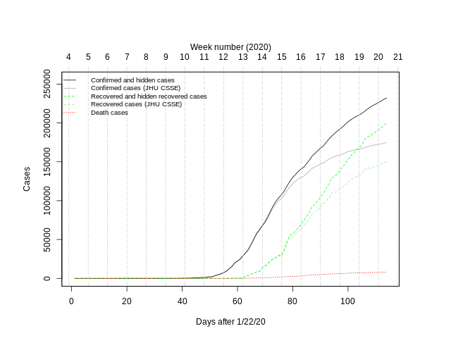

Situation

The growths rate is determined by logarithmic fitting of the confirmed cases:

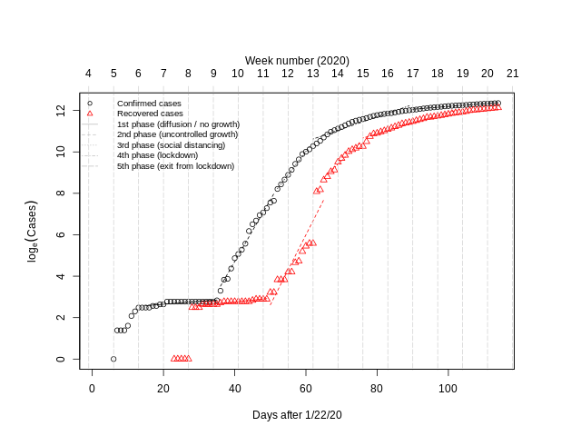

Situation - logarithmic scale

Basic Reproductive Number R0 has been determined from growths rate and median incubation time:

[figure not shown]

formula

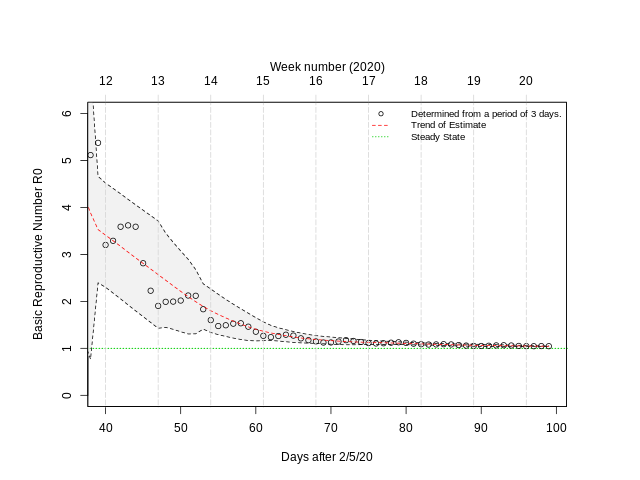

Situation - Basic Reproductive Number

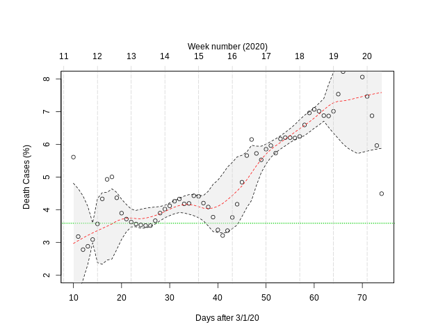

Death Casses

Hidden cases are calculated by the amount of death casses per day.

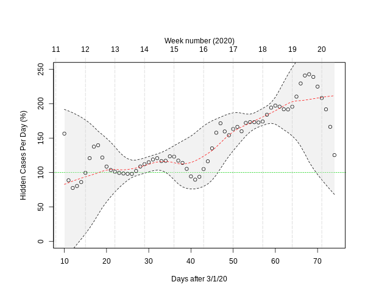

Hidden Casses

### Model vs Situation

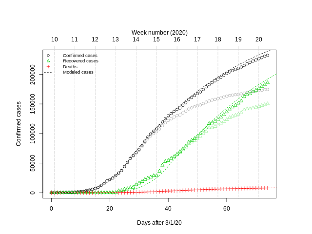

Model vs Situation

The predicted begin of a new phase is linked to a real event!

| Date | Event | Phase | Estimate |
| --- | --- | --- | --- |
| 03/01/20 | begin of simulation | uncontrolled growth | 0 |
| 03/12/20 | who declares pandemic | social distancing | 11.713200 (03/12/20) |
| 03/22/20 | contact restriction | shutdown | 21.946100 (03/22/20) |

### Forecast (250 Days)

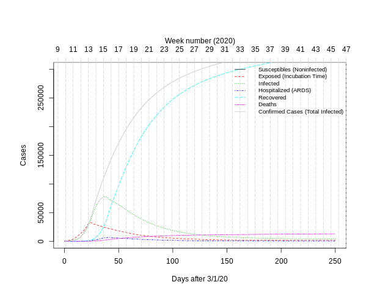

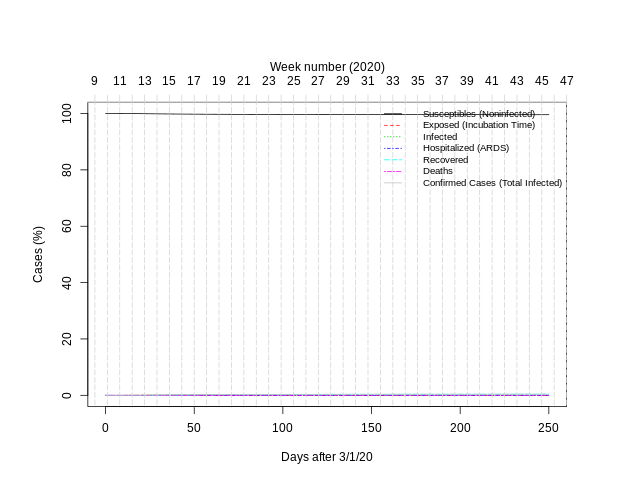

Forecast as Fraction

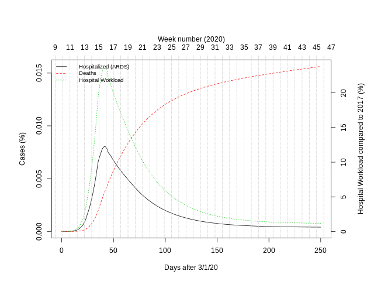

Forecast ARDS

### Scenario 1 - no social distancing and no lock down

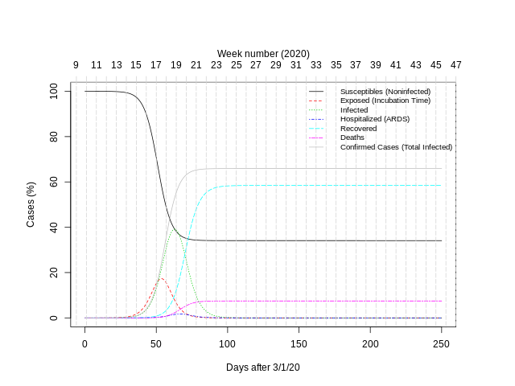

Forecast as Fraction

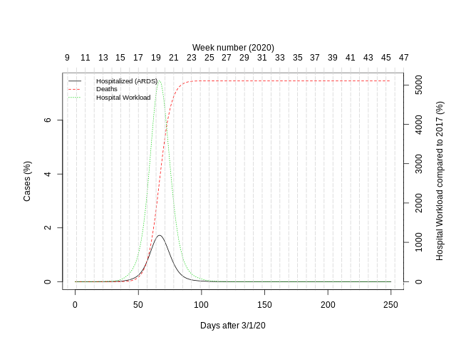

Forecast ARDS

The day of health system crash is close to the timepiont the shutdown if an

[figure not shown]

of 1 after shutdown is assumed.

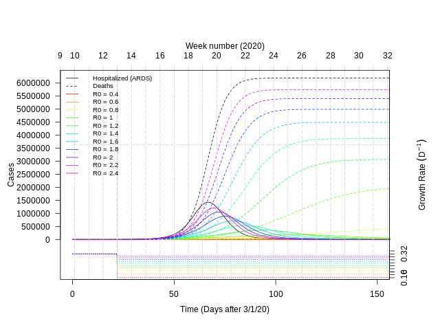

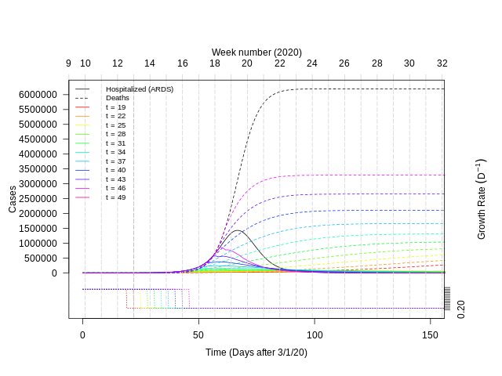

### Scenario 2 - End of lock down after day 50 without social distancing (worest case)

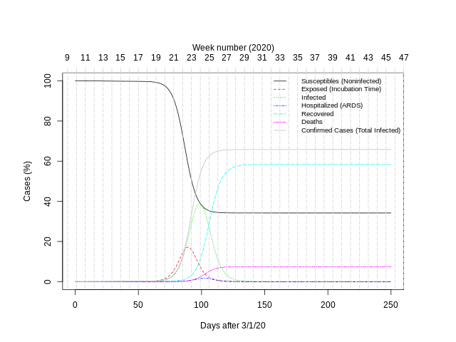

Forecast as Fraction

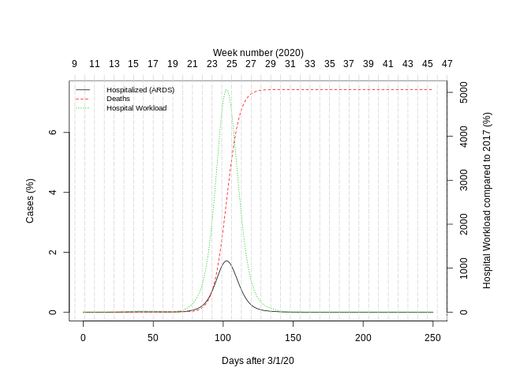

Forecast ARDS

### Scenario 3 - End of lock down after day 50 with social distancing (better case)

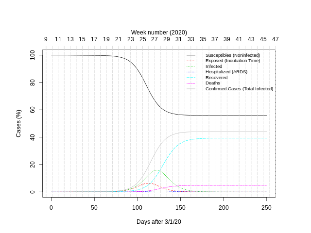

Forecast as Fraction

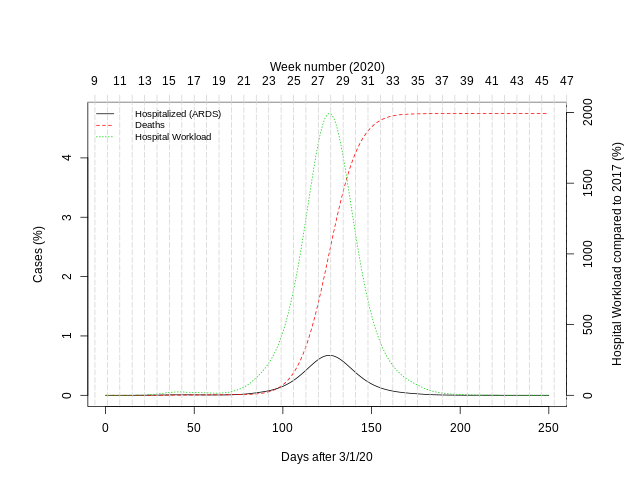

Forecast ARDS

## References

- https://www.rki.de/DE/Content/InfAZ/N/Neuartiges_Coronavirus/Steckbrief.html
- …